# STATS 4250 Project

# Data Set (colon)

## Description

These are data from one of the first successful trials of adjuvant chemotherapy for colon cancer. Levamisole is a low-toxicity compound previously used to treat worm infestations in animals; 5-FU is a moderately toxic (as these things go) chemotherapy agent. There are two records per person, one for recurrence and one for death.

## Variables

- id: id
- study: 1 for all patients
- rx: Treatment - Obs(ervation), Lev(amisole), Lev(amisole)+5-FU *sex: 1=male* age: in years
- obstruct: obstruction of colon by tumour
- perfor: perforation of colon
- adhere: adherence to nearby organs
- nodes: number of lymph nodes with detectable cancer
- time: days until event or censoring
- status: censoring status
- differ: differentiation of tumour (1=well, 2=moderate, 3=poor)
- extent: Extent of local spread (1=submucosa, 2=muscle, 3=serosa, 4=contiguous structures)
- surg: time from surgery to registration (0=short, 1=long)
- node4: more than 4 positive lymph nodes
- etype: event type: 1=recurrence,2=death

The event time is **time** (days until event or censoring), censor status is **status**. Here’s what the data set looks like

```r
library(survival)
library(survminer) # for ggcoxfunctional
head(colon)
```

|  | id | study | rx | sex | age | obstruct | perfor | adhere | nodes | status | differ | extent | surg | node4 | time | etype |
| --- | --- | --- | --- | --- | --- | --- | --- | --- | --- | --- | --- | --- | --- | --- | --- | --- |
| 1 | 1 | 1 | Lev+5FU | 1 | 43 | 0 | 0 | 0 | 5 | 1 | 2 | 3 | 0 | 1 | 1521 | 2 |
| 2 | 1 | 1 | Lev+5FU | 1 | 43 | 0 | 0 | 0 | 5 | 1 | 2 | 3 | 0 | 1 | 968 | 1 |
| 3 | 2 | 1 | Lev+5FU | 1 | 63 | 0 | 0 | 0 | 1 | 0 | 2 | 3 | 0 | 0 | 3087 | 2 |
| 4 | 2 | 1 | Lev+5FU | 1 | 63 | 0 | 0 | 0 | 1 | 0 | 2 | 3 | 0 | 0 | 3087 | 1 |
| 5 | 3 | 1 | Obs | 0 | 71 | 0 | 0 | 1 | 7 | 1 | 2 | 2 | 0 | 1 | 963 | 2 |
| 6 | 3 | 1 | Obs | 0 | 71 | 0 | 0 | 1 | 7 | 1 | 2 | 2 | 0 | 1 | 542 | 1 |

## Initial Thoughts

possible covariates:

- age
- sex
- rx
- obstruct
- perfor
- adhere
- nodes
- differ
- extent
- surg
- node4
- etype

```r
# this code will look at one-variable Cox PH models, and report
# the resulting beta coefficients, test statistics, and p-values
testCovariates <- c("age","sex","rx","obstruct","perfor","adhere","nodes","differ","extent","surg","node4","etype")
univ_formulas <- sapply(testCovariates,function(x)as.formula(paste('Surv(time,status)~',x)))
univ_models <- lapply(univ_formulas,function(x){coxph(x,data=colon)})
# Extract data
univ_results <- lapply(univ_models,function(x){
  x<-summary(x)
  p.value<-signif(x$wald["pvalue"],digits=3)
  wald.test<-signif(x$wald["test"],digits=3)
  beta<-signif(x$coef[1], digits=3);#coeficient beta
  res<-c(beta, wald.test, p.value)
  names(res)<-c("beta", "wald.test","p.value")
  return(res)
#return(exp(cbind(coef(x),confint(x))))
  })
res <- t(as.data.frame(univ_results))
format(as.data.frame(res),scientific=FALSE)
```

|  | beta | wald.test | p.value |
| --- | --- | --- | --- |
| age | -0.00244 | 0.76 | 0.382000000000000006217248937900876626372337341 |
| sex | -0.03360 | 0.26 | 0.609999999999999986677323704498121514916419983 |
| rx | -0.02090 | 33.10 | 0.000000064500000000000001845813541075103092481 |
| obstruct | 0.24200 | 9.07 | 0.002599999999999999880651024852795671904459596 |
| perfor | 0.26400 | 2.16 | 0.141999999999999987343457519273215439170598984 |
| adhere | 0.31500 | 13.20 | 0.000284000000000000018488682806960810012242291 |
| nodes | 0.08680 | 192.00 | 0.000000000000000000000000000000000000000000119 |
| differ | 0.30500 | 20.50 | 0.000005859999999999999798351406343766001327822 |
| extent | 0.57700 | 55.30 | 0.000000000000101999999999999994515315398662229 |
| surg | 0.24600 | 11.70 | 0.000610999999999999997973842980059089313726872 |

[output cut: 2 more lines]

## Double Checking Numerical Predictors

### Age

```r
fit <- coxph(Surv(time,status)~age,data=colon)
fit
```

```
## Call:
## coxph(formula = Surv(time, status) ~ age, data = colon)
##
##          coef exp(coef)  se(coef)      z     p
## age -0.002444  0.997559  0.002795 -0.874 0.382
##
## Likelihood ratio test=0.76  on 1 df, p=0.3831
## n= 1858, number of events= 920
```

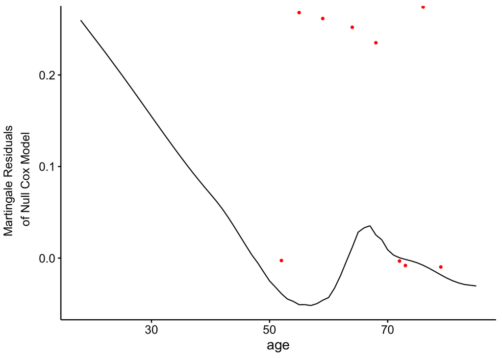

```r
ggcoxfunctional(Surv(time, status) ~ age, data = colon)
```

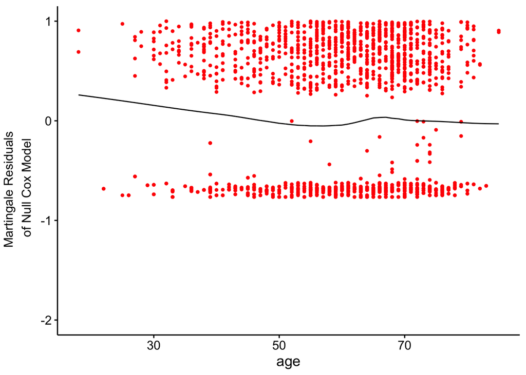

```r
ggcoxfunctional(Surv(time,status)~age,data=colon,ylim=c(-2,1))
```

```r
# Change Z.range to your desired values
Z.range<- seq(45,55,1) # possible age values
mincutoff <- 0
minaic <- 1e10
for(cutoff in Z.range){
  # Change time, status, age, colon to your data set and variable
fit.temp <- coxph(Surv(time,status)~age*I(age>cutoff),data=colon)
aic <- AIC(fit.temp)
cat("cutoff: Z >", cutoff, "; AIC =", aic, "\n")
if(aic < minaic){
  mincutoff <- cutoff
  minaic <- aic
}
}
```

```
## cutoff: Z > 45 ; AIC = 13209.95
## cutoff: Z > 46 ; AIC = 13210.75
## cutoff: Z > 47 ; AIC = 13209.4
## cutoff: Z > 48 ; AIC = 13210.31
## cutoff: Z > 49 ; AIC = 13210.44
## cutoff: Z > 50 ; AIC = 13210.4
## cutoff: Z > 51 ; AIC = 13209.83
## cutoff: Z > 52 ; AIC = 13210.09
## cutoff: Z > 53 ; AIC = 13210.1
## cutoff: Z > 54 ; AIC = 13210.1
## cutoff: Z > 55 ; AIC = 13209.81
```

```r
cat("optimal cutoff: Z >", mincutoff, "; AIC =", minaic, "\n")
```

```
## optimal cutoff: Z > 47 ; AIC = 13209.4
```

```r
fit2 <- coxph(Surv(time,status)~age*I(age>47),data=colon)
AIC(fit,fit2)
```

|  | df | AIC |
| --- | --- | --- |
| fit | 1 | 13213.12 |
| fit2 | 3 | 13209.40 |

### nodes

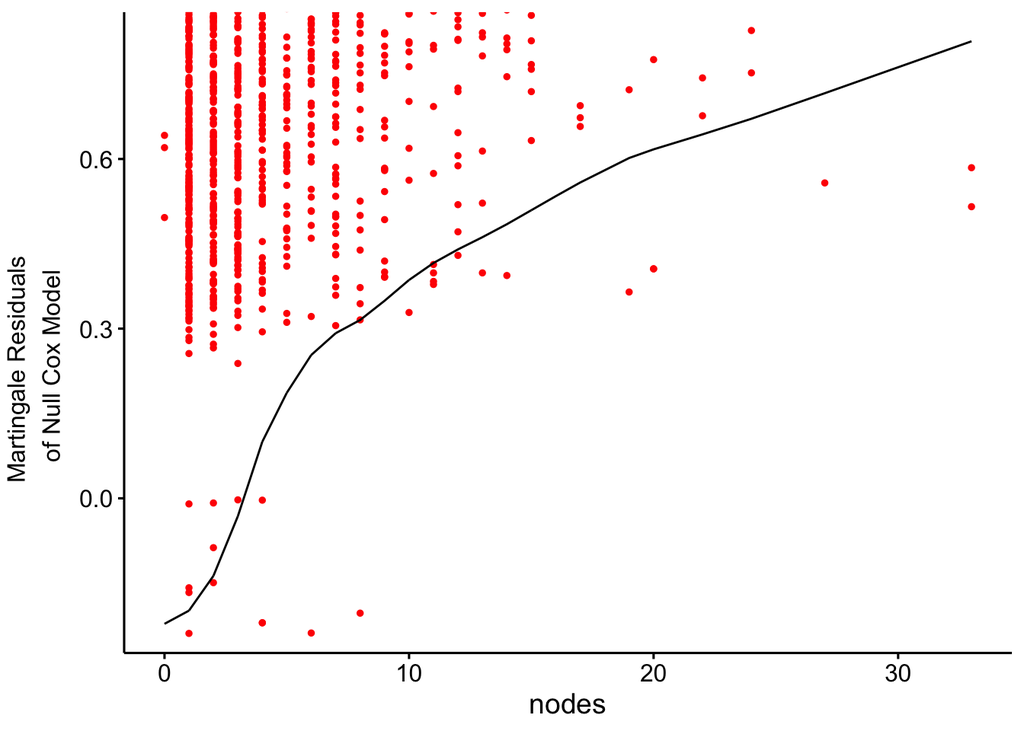

```r
 I <- which(is.na(colon$nodes)) # indices where nodes is NA
colonTemp <- colon[-I,]
ggcoxfunctional(Surv(time,status)~nodes,data=colonTemp)
```

```r
fit1 <- coxph(Surv(time,status)~nodes,data=colon)
fit2 <- coxph(Surv(time,status)~sqrt(nodes),data=colon)
fit3 <- coxph(Surv(time,status)~log(nodes+1),data=colon)
fit1$coefficients; fit2$coefficients; fit3$coefficients;
```

```
##      nodes
## 0.08677759
```

```
## sqrt(nodes)
##   0.5106492
```

```
## log(nodes + 1)
##      0.7198119
```

```r
anova(fit1,fit2,fit3)
```

|  | loglik | Chisq | Df | P(>\|Chi\|) |
| --- | --- | --- | --- | --- |
| 1 | -6357.410 | NA | NA | NA |
| 2 | -6340.906 | 33.008266 | 0 | 0 |
| 3 | -6336.377 | 9.056796 | 0 | 0 |

```r
AIC(fit1,fit2,fit3)
```

|  | df | AIC |
| --- | --- | --- |
| fit1 | 1 | 12716.82 |
| fit2 | 1 | 12683.81 |
| fit3 | 1 | 12674.75 |

```r
fit3
```

```
## Call:
## coxph(formula = Surv(time, status) ~ log(nodes + 1), data = colon)
##
##                   coef exp(coef) se(coef)     z      p
## log(nodes + 1) 0.71981   2.05405  0.05205 13.83 <2e-16
##
## Likelihood ratio test=175.2  on 1 df, p=< 2.2e-16
## n= 1822, number of events= 897
##    (36 observations deleted due to missingness)
```

### adhere

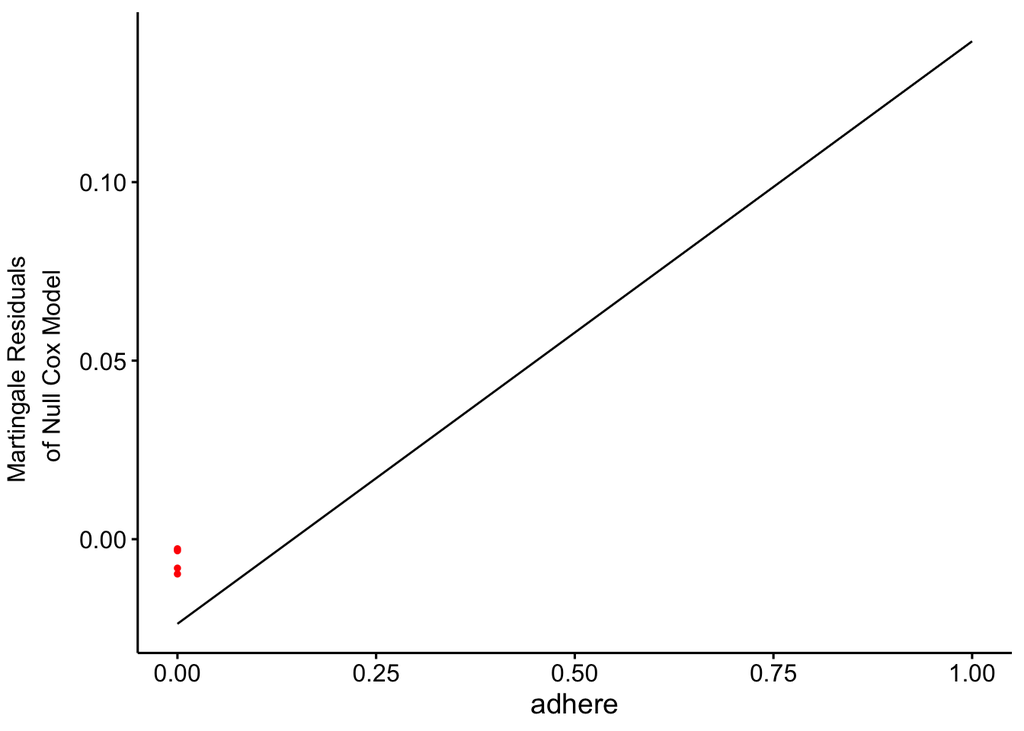

```r
ggcoxfunctional(Surv(time, status) ~ adhere, data = colon)
```

### differ

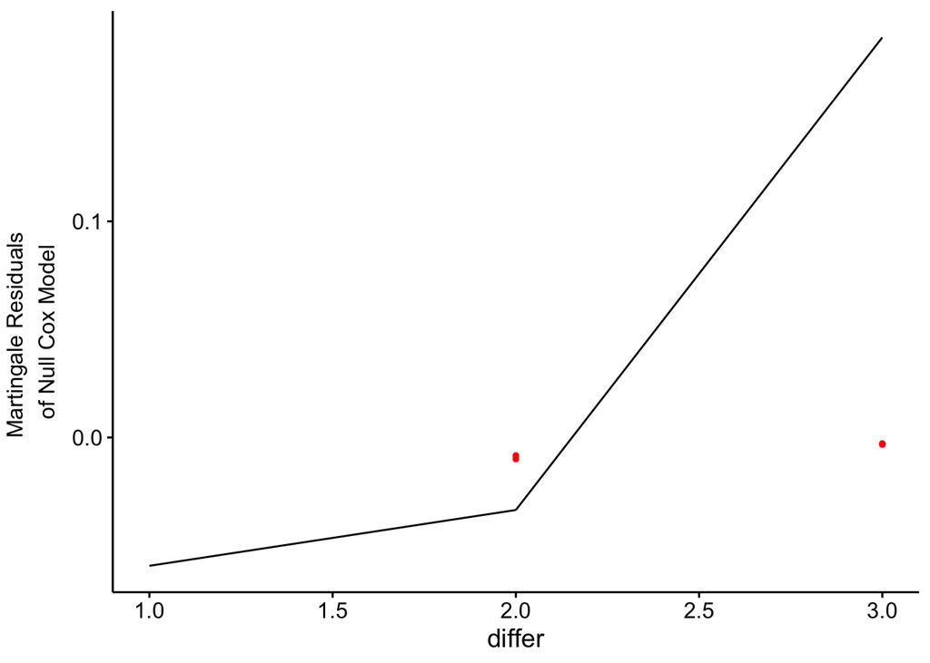

```r
I <- which(is.na(colon$differ))
ggcoxfunctional(Surv(time, status) ~ differ, data = colon[-I,])
```

### node4

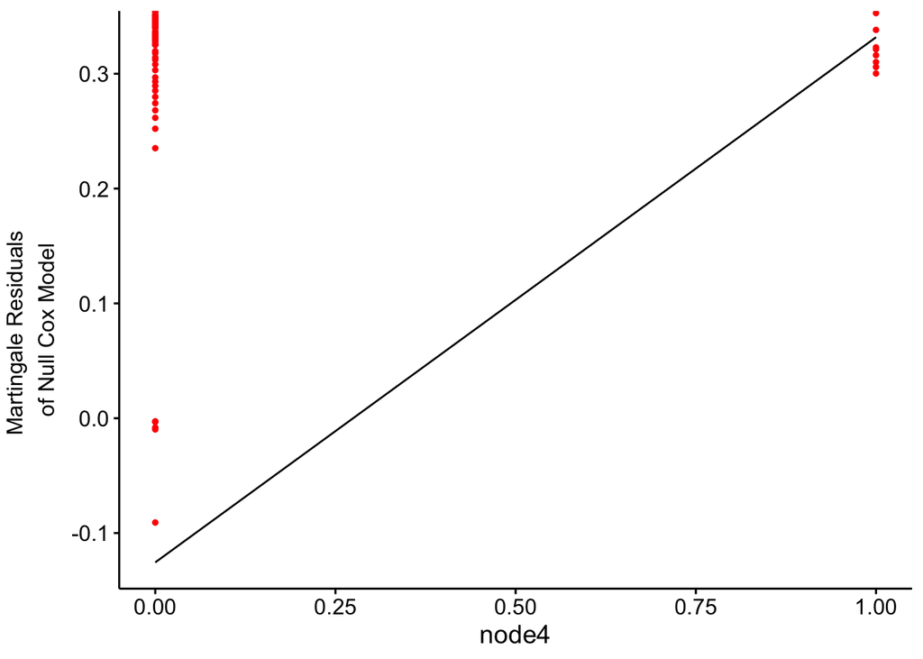

```r
ggcoxfunctional(Surv(time, status) ~ node4, data = colon)
```

### extent

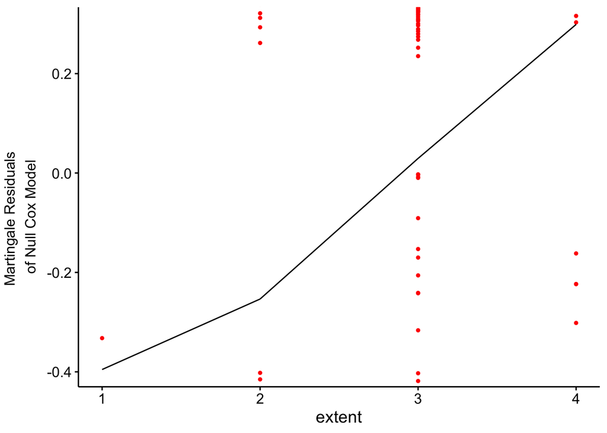

```r
ggcoxfunctional(Surv(time, status) ~ extent, data = colon)
```

### perfor

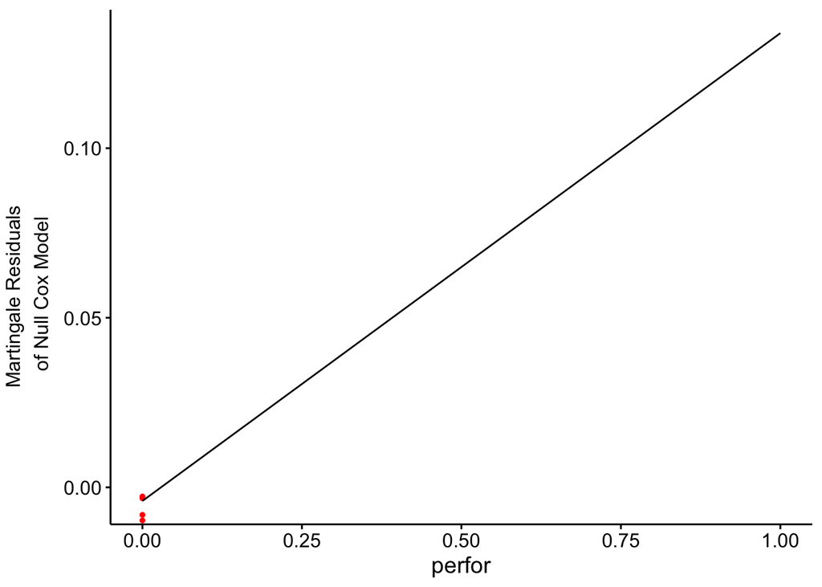

```r
ggcoxfunctional(Surv(time, status) ~ perfor, data = colon)
```

### The Model Thus Far

```r
fit <- coxph(Surv(time,status)~age*I(age>47)+log(nodes+1)+rx+sex+obstruct+differ,data=colon)
```

## Removing Predictors, Testing Assumptions

```r
summary(fit)
```

```
## Call:
## coxph(formula = Surv(time, status) ~ age * I(age > 47) + log(nodes +
##     1) + rx + sex + obstruct + differ, data = colon)
##
##   n= 1776, number of events= 876
##    (82 observations deleted due to missingness)
##
##                          coef exp(coef)  se(coef)      z Pr(>|z|)
## age                 -0.002439  0.997564  0.013280 -0.184  0.85428
## I(age > 47)TRUE     -0.738132  0.478006  0.608861 -1.212  0.22539
## log(nodes + 1)       0.699584  2.012915  0.053209 13.148  < 2e-16 ***
## rxLev               -0.045304  0.955707  0.079307 -0.571  0.56783
## rxLev+5FU           -0.449815  0.637746  0.086022 -5.229  1.7e-07 ***
## sex                 -0.079823  0.923280  0.067980 -1.174  0.24031
## obstruct             0.233286  1.262743  0.083813  2.783  0.00538 **
## differ               0.189536  1.208689  0.069348  2.733  0.00627 **
## age:I(age > 47)TRUE  0.012073  1.012147  0.014053  0.859  0.39025
## ---
## Signif. codes:  0 '***' 0.001 '**' 0.01 '*' 0.05 '.' 0.1 ' ' 1
##
##                     exp(coef) exp(-coef) lower .95 upper .95
## age                    0.9976     1.0024    0.9719    1.0239
## I(age > 47)TRUE        0.4780     2.0920    0.1449    1.5765
## log(nodes + 1)         2.0129     0.4968    1.8136    2.2342
## rxLev                  0.9557     1.0463    0.8181    1.1164
## rxLev+5FU              0.6377     1.5680    0.5388    0.7549
## sex                    0.9233     1.0831    0.8081    1.0549
## obstruct               1.2627     0.7919    1.0715    1.4882
## differ                 1.2087     0.8273    1.0551    1.3847
## age:I(age > 47)TRUE    1.0121     0.9880    0.9846    1.0404
##
## Concordance= 0.648  (se = 0.009 )
## Likelihood ratio test= 223.9  on 9 df,   p=<2e-16
## Wald test            = 239.1  on 9 df,   p=<2e-16
## Score (logrank) test = 244.7  on 9 df,   p=<2e-16
```

## Testing the Cox PH Assumption

```r
test.fit <- cox.zph(fit)
test.fit
```

```
##                   chisq df       p
## age              0.0759  1  0.7830
## I(age > 47)      2.0431  1  0.1529
## log(nodes + 1)   5.1386  1  0.0234
## rx               1.6797  2  0.4318
## sex              2.2241  1  0.1359
## obstruct         8.7645  1  0.0031
## differ          20.1628  1 7.1e-06
## age:I(age > 47)  1.1575  1  0.2820
## GLOBAL          42.1983  9 3.0e-06
```

### nodes

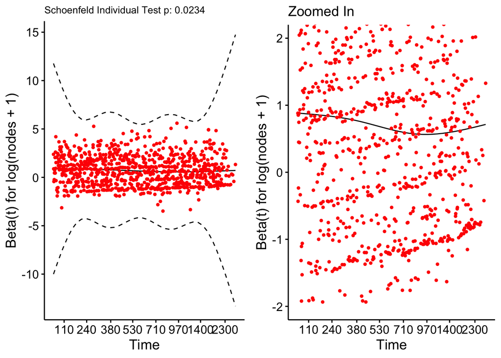

```r
par(mfrow=c(1,2))
library(gridExtra)
plot1 <- ggcoxzph(test.fit,var="log(nodes + 1)",font.main=c(10,"plain","black"))
plot2 <- ggcoxzph(test.fit,var="log(nodes + 1)",ylim=c(-2,2),font.main=c(14,"plain","black"),main="Zoomed In")
 grid.arrange(plot1[[1]],plot2[[1]],ncol=2)
```

### Obstruct

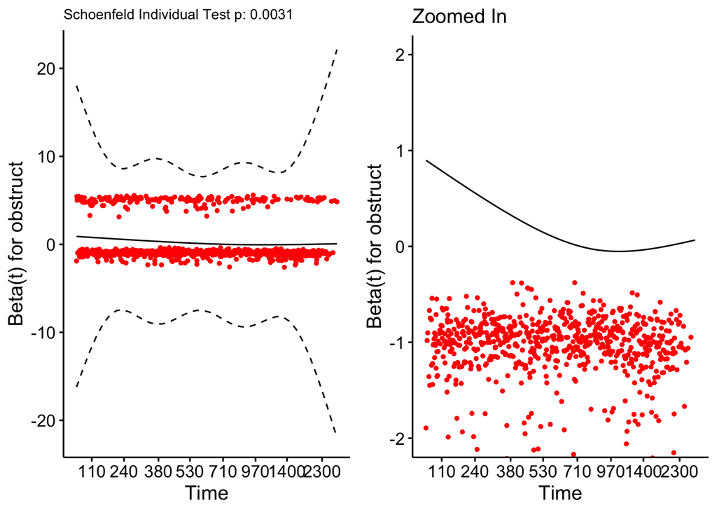

```r
plot1 <- ggcoxzph(test.fit,var="obstruct",font.main=c(10,"plain","black"))
plot2 <- ggcoxzph(test.fit,var="obstruct",ylim=c(-2,2),font.main=c(14,"plain","black"),main="Zoomed In")
grid.arrange(plot1[[1]],plot2[[1]],ncol=2)
```

### differ

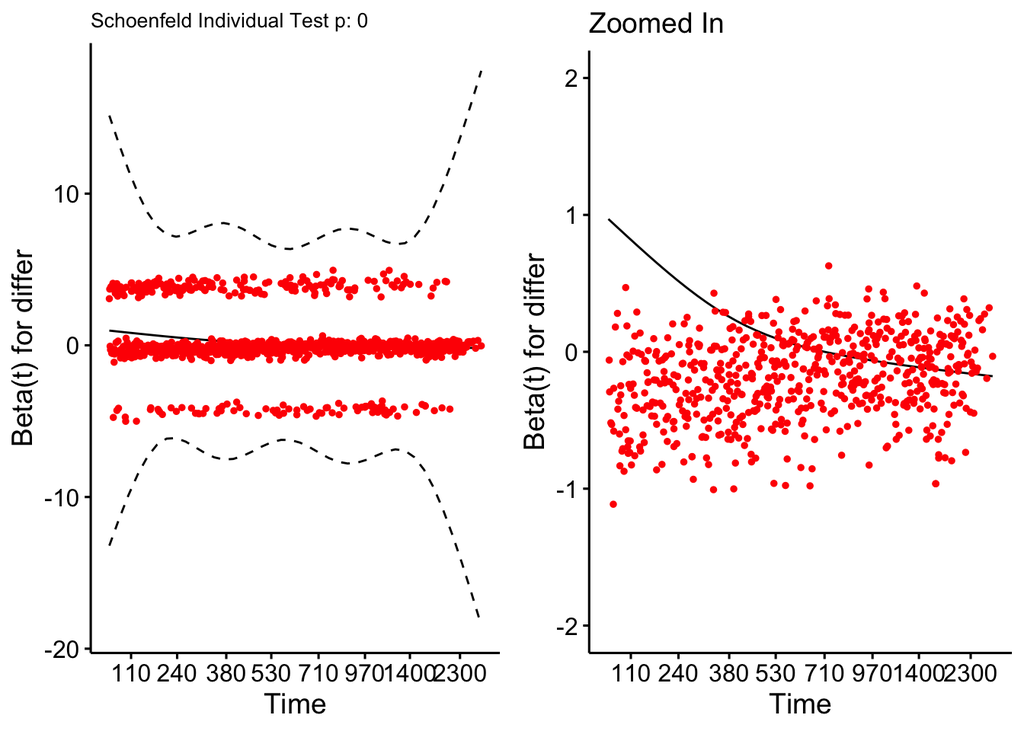

```r
plot1 <- ggcoxzph(test.fit,var="differ",font.main=c(10,"plain","black"))
plot2 <- ggcoxzph(test.fit,var="differ",ylim=c(-2,2), font.main=c(14,"plain","black"),main="Zoomed In")
grid.arrange(plot1[[1]],plot2[[1]],ncol=2)
```

## Removing Covariates

### differ

```r
fit1 <- coxph(Surv(time,status)~age*I(age>47)+log(nodes+1)+rx+sex+obstruct+I(differ>2),data=colon)
fit2 <- coxph(Surv(time,status)~age*I(age>47)+log(nodes+1)+rx+sex+obstruct+as.factor(differ),data=colon)
```

```r
temp <- cox.zph(fit1)
print(temp)
```

```
##                  chisq df       p
## age              0.106  1  0.7450
## I(age > 47)      2.183  1  0.1396
## log(nodes + 1)   5.032  1  0.0249
## rx               1.818  2  0.4030
## sex              2.322  1  0.1276
## obstruct         8.711  1  0.0032
## I(differ > 2)   27.940  1 1.3e-07
## age:I(age > 47)  1.259  1  0.2619
## GLOBAL          48.828  9 1.8e-07
```

```r
temp <- cox.zph(fit2)
print(temp)
```

```
##                    chisq df       p
## age                0.103  1  0.7488
## I(age > 47)        2.179  1  0.1399
## log(nodes + 1)     5.041  1  0.0248
## rx                 1.840  2  0.3985
## sex                2.332  1  0.1268
## obstruct           8.705  1  0.0032
## as.factor(differ) 28.216  2 7.5e-07
## age:I(age > 47)    1.252  1  0.2633
## GLOBAL            48.998 10 4.1e-07
```

### dealing with obstruct

```r
fit1 <- coxph(Surv(time,status)~age*I(age>47)+log(nodes+1)+rx+sex+obstruct:nodes,data=colon)
temp <- cox.zph(fit1)
print(temp)
```

```
##                  chisq df     p
## age              0.003  1 0.956
## I(age > 47)      1.702  1 0.192
## log(nodes + 1)   4.366  1 0.037
## rx               1.062  2 0.588
## sex              2.927  1 0.087
## age:I(age > 47)  0.824  1 0.364
## obstruct:nodes   2.693  1 0.101
## GLOBAL          14.584  8 0.068
```

### dealing with nodes

```r
fit2 <- coxph(Surv(time,status)~age*I(age>47)+sqrt(nodes)+rx+sex+obstruct:nodes,data=colon)
temp <- cox.zph(fit2)
print(temp)
```

```
##                    chisq df     p
## age              0.00313  1 0.955
## I(age > 47)      1.83909  1 0.175
## sqrt(nodes)      1.28009  1 0.258
## rx               1.10277  2 0.576
## sex              3.21297  1 0.073
## age:I(age > 47)  0.88100  1 0.348
## obstruct:nodes   1.95599  1 0.162
## GLOBAL          12.17689  8 0.143
```